# Geolocation analysis with Open Source Tools 2016 North American Ornithological Congress, Washington D.C.

## Removing/Fixing Twilight Outliers

The function twilightEdit may help to find outliers and either remove or edit them according to one rule:

The following code is fast and easily reproducible definition to edit outlier twilight times.

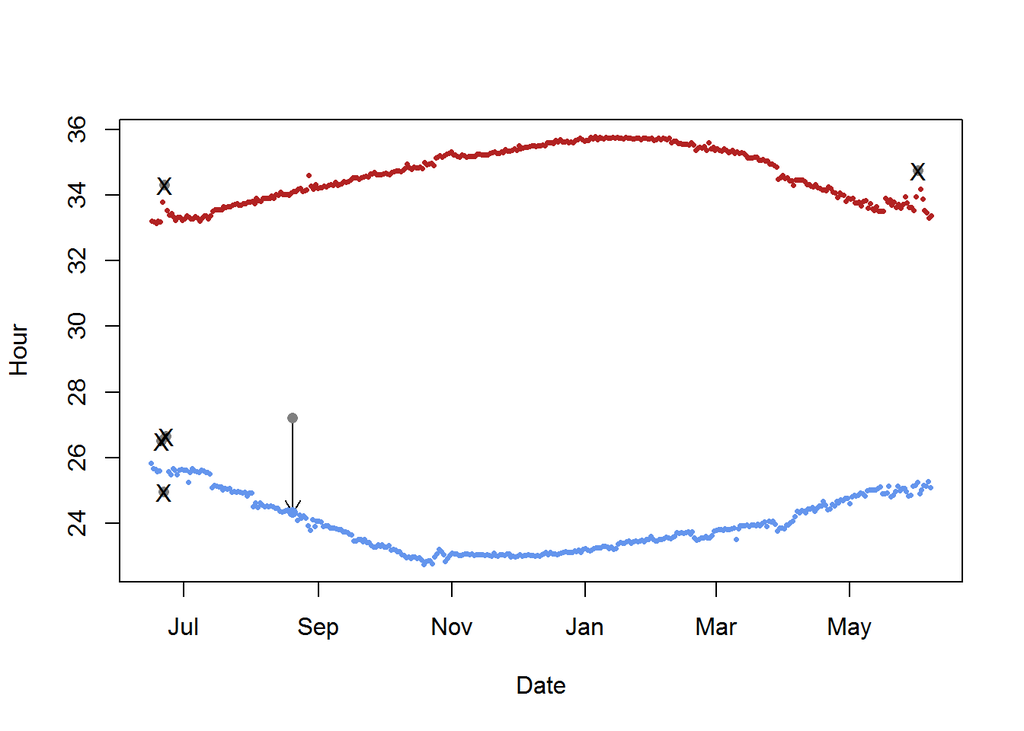

```r
twl <- twilightEdit(twilights = twl,
                    window = 4,           # two days before and two days after
                    outlier.mins = 45,    # difference in mins
                    stationary.mins = 25, # are the other surrounding twilights within 25 mins of one another
                    plot = TRUE)
```

This function provides a dataframe with both the edited twlight times (in column “Twilight”) and the original twilight times (in column “Twilight0”). Now that we have adjusted the twilights - we have new information in out `twl` file.

```
##              Twilight  Rise Deleted Edited           Twilight0
## 1 2011-06-16 01:49:43 FALSE   FALSE  FALSE 2011-06-16 01:49:43
## 2 2011-06-16 09:12:29  TRUE   FALSE  FALSE 2011-06-16 09:12:29
## 3 2011-06-17 01:39:29 FALSE   FALSE  FALSE 2011-06-17 01:39:29
## 4 2011-06-17 09:11:29  TRUE   FALSE  FALSE 2011-06-17 09:11:29
## 5 2011-06-18 01:38:59 FALSE   FALSE  FALSE 2011-06-18 01:38:59
## 6 2011-06-18 09:08:29  TRUE   FALSE  FALSE 2011-06-18 09:08:29
```

It’s a good idea to save this dataframe for future reference so that the edits made are documented and your analysis repeatable

```r
write.csv(twl, file = "Edited_twilights", quote = FALSE, row.names = FALSE)
```

Here is an image with the twilight outliers either adjusted or removed.

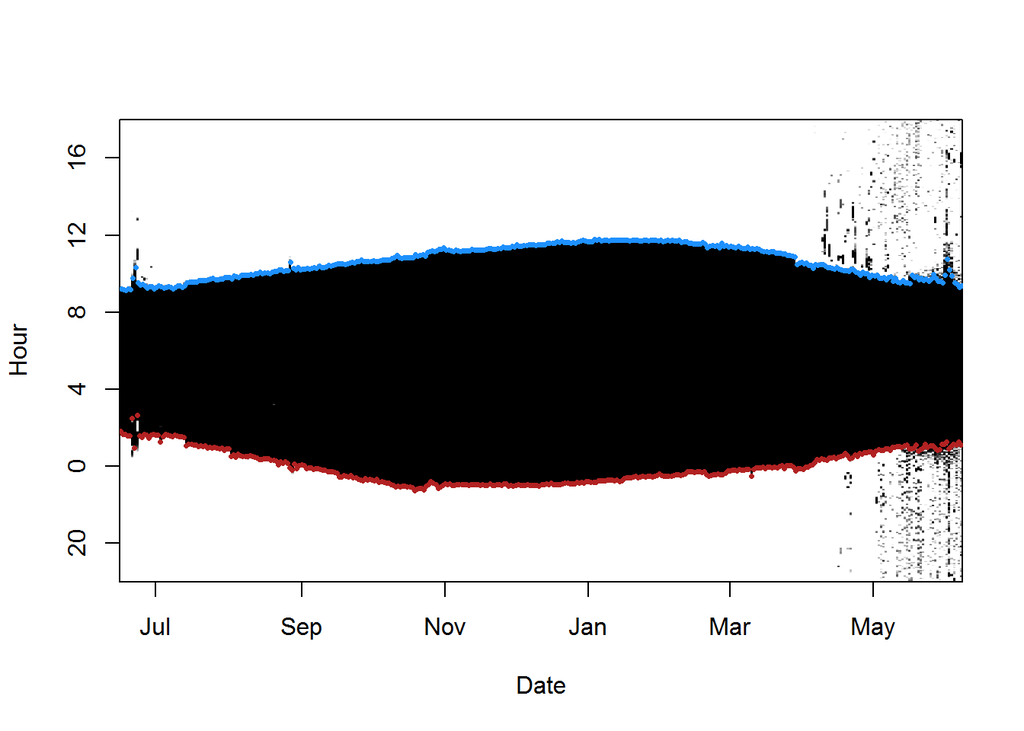

In order to take advantage of the edits - you can subset the data using when `Deleted` == FALSE this removes any of the twilights which were deleted.

```r
twl <- subset(twl, Deleted == FALSE)
```

Many tags record the maximum light value measured within a given time interval, in our example data set it records the maximum light level every two mins. You can double check the time interval by looking at the `.lig` file. Because the maximum light level is stamped with a time that corresponds to the end of the sampling period, we may want to to adjust the sunset times to the beginning of the sampling period, when the tag was most likely to encounter the highest light level. Note that this adjustment is not necessary if you plan to use FLightR.

```r
# Check the sampling interval of the geolocator
head(d.lig)
```

```
##                  Date Light
## 1 2011-06-15 21:06:00    44
## 2 2011-06-15 21:07:59    64
## 3 2011-06-15 21:09:59    64
## 4 2011-06-15 21:11:59    64
## 5 2011-06-15 21:13:59    64
## 6 2011-06-15 21:15:59    64
```

If you’re not convinced you can look at the difference between two consecutive light level readings

```r
d.lig$Date[3]-d.lig$Date[2]
```

```
## Time difference of 2 mins
```

Here we adjust the twilight time back to account for the maximum light level readings every 2 mins.

```r
twl <- twilightAdjust(twilights = twl,
                      interval = 120) # The unit here is seconds
```

Let’s truncate the data to include only the dates when we know the tag was on the bird.

```r
On_Bird <- as.POSIXct(c("2011-06-26", "2012-05-11"), tz = "GMT")
```

Now let’s make a light image and use abline() to draw some orange lines that enclose the time period when the geolocator was on the bird.

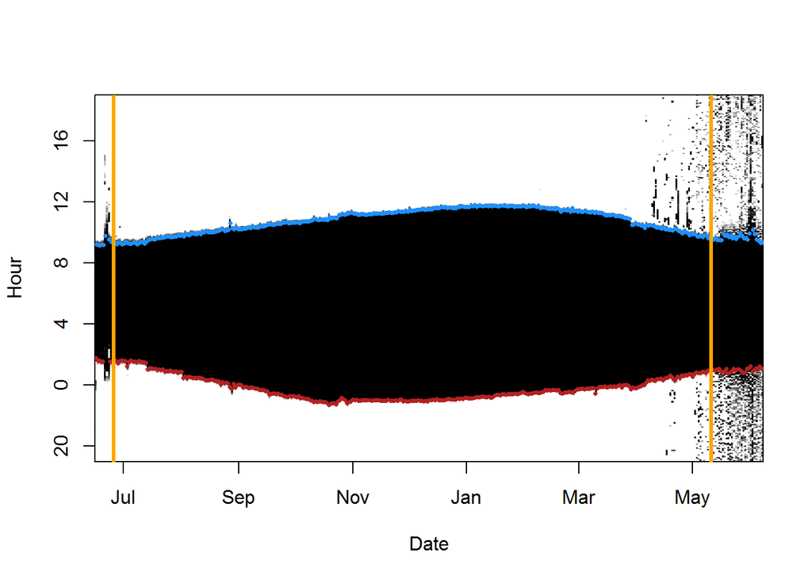

```r
lightImage(d.lig, offset = 19)
tsimagePoints(twl$Twilight, offset = 19, pch = 16, cex = 0.5,
              col = ifelse(twl$Rise, "dodgerblue", "firebrick"))

abline(v  = On_Bird, col  ="orange", lwd = 3)
```

You could also specify the dates when the tag was on the bird by using the `locator()` function and clicking on the light image to specify the dates.

```r
lightImage(d.lig, offset = 19)
tsimagePoints(twl$Twilight, offset = 19, pch = 16, cex = 0.5,
              col = ifelse(twl$Rise, "dodgerblue", "firebrick"))

On_Bird <- as.POSIXct(locator(n=2)$x, origin = "1970-01-01", tz = "GMT")
```

The following code subsets the twilight data to include only those data between the capture dates.

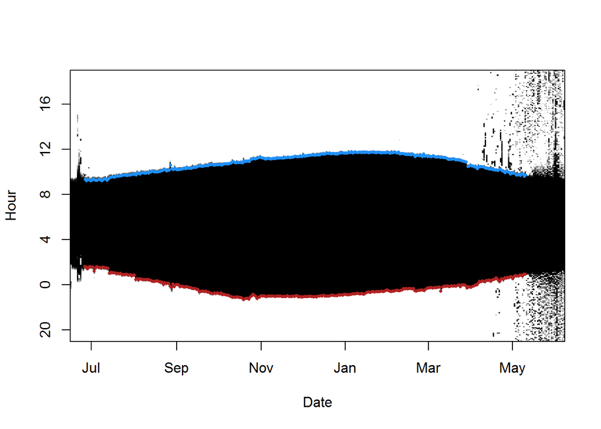

```r
twl <- twl[twl$Twilight > On_Bird[1] & twl$Twilight < On_Bird[2],]
##plot just the on-bird twilights on top of a light image.
lightImage(d.lig, offset = 19)
tsimagePoints(twl$Twilight, offset = 19, pch = 16, cex = 0.5,
              col = ifelse(twl$Rise, "dodgerblue", "firebrick"))
```

back to top

[figure not shown]

# SGAT

## Calibration

Calibration serves two purposes in light leve geolocation. First it generates a sun-elevation angle (with respect to the horizon) or zenith angle (with respect to directly overhead), and second it allows us to quantify the error distribution around our estimates of sunrise and sunset. Calibration requires light level data taken at a known location so that we can compare the light level data to calculated sun positions. With this information we can first determine the sun angle associated with our threshold light value, and then use the threshold to generate estimates of sunrise and sunset that are compared with known (calculated) twilight time to give us an error distribution.

### Why is the sun-elevation angle / Zenith angle important?

> The sun-elevation angle / zenith angle is needed to determine the geographic location based on light-levels. As the animal migrates the time of sun-rise / sun-set will change corresponding to the local light-levels the individual is experiencing. We then use the sun-elevation angle along with the corresponding threshold level to determine where the bird must have been to exhibit twilight times associtated with the light-levels recorded by the geolocator.

### What affects the sun-elevation / zenith angle and how does that influence locations?

> A lot of factors can influence the sun-elevation angle. Weather, the animals behavior, habitat, and topography can all influence the sun-elevation / zenith angle. Picture the following senario. Let’s assume you place a tag on a bird on the eastern slope of a mountain range in a forested habitat. You use your calibration data to estimate the sun-elevation / zenith angle and find that the angle suggests that the twilight times represent the time when the sun is 3 degrees below the horizon (sun-elevation angle = -3, Zenith angle = -93). Now let’s assume the bird begins to migrate and crosses over the mountains to a westerly facing slope. Now the horizon is obstructed by the mountains and because of this the sun needs to be above the horizon by 1 degree for the light levels to cross the threshold. The sun elevation angle / zenith angle has changed but in our analysis we assume the sun is 3 degrees below the horizon when the light levels cross the threshold.

> *What happens to the estimated position of the bird relative to the ‘true’ position if we use -3 vs. 1 for a sun-elevation / zenith angle? Why?*

## Capture location

To perform calibration we must have data from a known location (usually the tag deployment or animal recapture site). It is best if the tag is on the animal during the calibration period. Let’s create an object to store the capture location.

```r
# Calibration Coordinates
CapLocs <- cbind(-80.46,42.62) # Longitude, latitude
```

Now that we have the capture location stored we need to make a subset of the twilight object (`twl`) we created earlier to include only dates when the animal was at the capture location. You can do this several ways. First, you can use personal observations (i.e., field work ended 1 August and the bird was still on territory) or the biology of the bird (i.e., stationary period ends when nestlings hatch around June 1). If you know an appropriate stationary period, then you can simply subset the data as follows:

```r
  cal <- subset(twl, twl$Twilight < as.POSIXct("2011-07-06", "GMT"))
```

This should give you all the twlights before July 6.

The alternative is to use the the light-level information direclty off the geolocator to determine when the animal was at the capture location. In order to use the second approach we need to know what the actual twilight events are and how they match up to the observed twilights derived from the geolocator data.

```r
  Times <- seq(from = d.lig$Date[1],
                 to = d.lig$Date[length(d.lig$Date)],
                 by = "day")

  rise <- rep(c(TRUE, FALSE), length(Times))


# making predicted twilight times given location and zenith #

  KnownTwl <- data.frame(Twilight = twilight(rep(Times, each = 2),
                                                 lon = CapLocs[1],
                                                 lat = CapLocs[2],
                                                 rise = rise,
                                                 zenith = 94),
                         Rise = rise)
```

Once we have the known twilight times from the capture location you can plot the light data from the geolocator (`d.lig`) and overlay the known twilight times from the capture location. The sun rise at the known location is shown in blue and the sunset is shown in red. When the light data from the tag corresponds with the known twilights at the capture location the animal was likely stationary at/around the capture site. When the measured light levels deviate from the known twilights the bird was somewhere else. You can use the `locator()` function to click on the image to determine dates, or you can create an R object that specifies the dates.

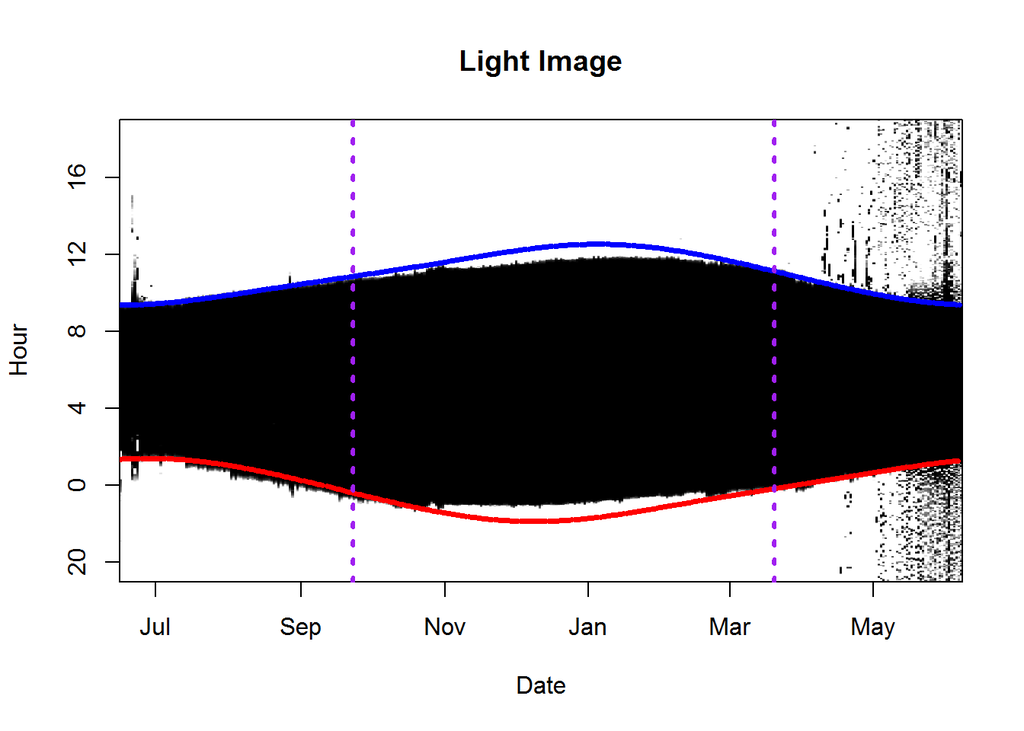

```r
  lightImage(d.lig,
             offset = 19,
             zlim = c(0,64),
             main = "Light Image")

  tsimagePoints(KnownTwl$Twilight,
                offset = 19,
                pch = 16, cex = 0.5,
                col = ifelse(KnownTwl$Rise, "blue", "red"))

  # adds line at two equinoxes for reference. Change the dates if necessary (can vary by year) #
  eqnx<-as.POSIXct(c("2011-09-23", "2012-03-20"), tz = "GMT")
  abline(v = eqnx, lwd=3, lty=3, col="purple")
```

From the image above it looks like the measured and known twilights correspond when until sometime in July. Here, we’ll use all the data until July 15, 2011 for the calibration period.

```r
calibrationPeriod <- subset(twl, Twilight0 < as.POSIXct("2011-07-15", "GMT"))
str(calibrationPeriod)
```

```
## 'data.frame':    38 obs. of  5 variables:
##  $ Twilight : POSIXct, format: "2011-06-26 01:38:16" "2011-06-26 09:21:26" ...
##  $ Rise     : logi  FALSE TRUE FALSE TRUE FALSE TRUE ...
##  $ Deleted  : logi  FALSE FALSE FALSE FALSE FALSE FALSE ...
##  $ Edited   : logi  FALSE FALSE FALSE FALSE FALSE FALSE ...
##  $ Twilight0: POSIXct, format: "2011-06-26 01:40:16" "2011-06-26 09:21:26" ...
```

## Sun-elevation / Zenith

You can get a quick and easy sun angle with the getElevation package in GeoLight. But first you have to get the calibration data into the special “tFirst/tSecond” format that GeoLight sometimes uses.

```r
  ##change data format
  cal2 <- data.frame(tFirst = calibrationPeriod$Twilight[1:(nrow(calibrationPeriod)-1)],
                     tSecond =  calibrationPeriod$Twilight[2:nrow( calibrationPeriod)],
                     type = abs( calibrationPeriod$Rise[1:(nrow(calibrationPeriod)-1)]-2))

  ##apply getElevation"
  sunAngle <- GeoLight::getElevation(twl = cal2,
                           known.coord = CapLocs,
                           plot = FALSE,
                           lnorm.pars = FALSE)

  ##sunAngle is the angle of the sun relative to the horizon where the horizon is zero.
  ##Positive values are above the horizon and negative values are below the horizon.
  sunAngle
```

```
##  med.elev
## -5.468884
```

Determining the sun elevation angle–here called the Zenith angle–for SGAT. A Zenith angle is the angle of the sun with respect to a verticle line. If the sun is directly overhead, the angle is zero. If the sun is on the horizon, the angle is about 90 degrees. For an SGAT analysis it is often best to use a zenith angle from the high end of the distrubution of zenith angles derived from the calibration data. In the example below we take the 95th quantile. Remember that a larger zenith angle means that the sun is lower in the sky.

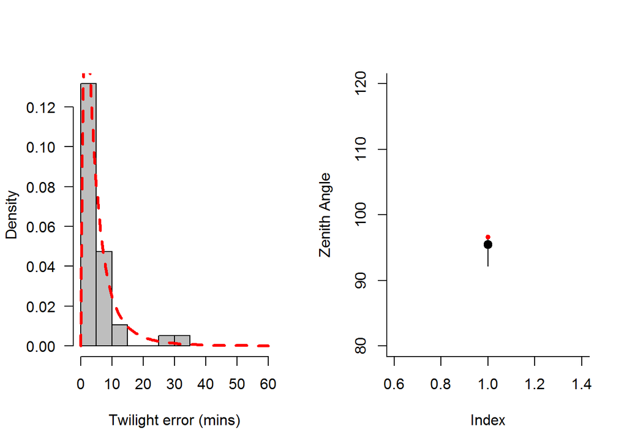

```r
  library(MASS)

  # Calculate solar time from calibration data
  sun <- solar(calibrationPeriod[,1])

  # Adjust the solar zenith angle for atmospheric refraction
  zenithAngle <- refracted( zenith(sun = sun,
                                   lon = CapLocs[1],
                                   lat = CapLocs[2]))

  twilight_time <- twilight(tm = calibrationPeriod[,1],
                          lon = CapLocs[1],
                          lat = CapLocs[2],
                          rise = calibrationPeriod[,2],
                          zenith = quantile(zenithAngle,probs=0.95))

  # Determine the difference in minutes from when the sun rose and the geolocator said it rose
  twl_deviation <- ifelse(calibrationPeriod$Rise,
                          as.numeric(difftime(calibrationPeriod[,1], twilight_time, units = "mins")),
                          as.numeric(difftime(twilight_time, calibrationPeriod[,1], units = "mins")))

  # Describe the distribution of the error
  twl.dist <- fitdistr(abs(twl_deviation), "log-Normal")

  # save the Twilight model parameters
  alpha <- c(twl.dist$estimate[1], twl.dist$estimate[2])

# Make some plots to visualize the data
par(mfrow=c(1,2))
hist(abs(twl_deviation), freq = F,
     yaxt="n",
     xlim = c(0, 60),
     breaks=10,
     col="gray",
     main = "",
     xlab = "Twilight error (mins)")
axis(2,las=2)
  lines(seq(0,60, length = 100),
        dlnorm(seq(0,60, length = 100), alpha[1], alpha[2]), col ="red",lwd = 3, lty = 2)

#Zenith angle plot
par(bty="l")
plot(median(zenithAngle,na.rm=TRUE),ylim = c(80,120),pch=19,cex=1.25,ylab="Zenith Angle")
segments(1,quantile(zenithAngle,probs=0.025),1,quantile(zenithAngle,probs=0.975))
points(1,max(zenithAngle,na.rm=TRUE),col="red",pch=20)
```

Here we assign the zenith that we will use in the analyses. If using a simple threshold approach (`GeoLight`) the median zenith Angle is probably good enough.

```r
Zenith <- quantile(zenithAngle, probs = 0.95)
```

## Inital Path

Now that we have the error distribution around known sunrise and sunset times as well as the zenith angle, we can look at the location data. As a reminder, we are looking here at a subset o the data which includes twilights that 1) occurred after the first calibrartion date (presumably the deployment date) and 2) were not deleted according to the output of twilightEdit().

**Important** - the tol setting in the `thresholdPath` model sets the tolerance around equinox (i.e. filter out those points). Latitudinal estimates are unrelibale around the equinox periods because the change in day length is similar everywhere. `tol` values = 0 indicates save all points - larger tol values (0.2) filter out quite a few points. For this example, I set the tolerance to 0 (not the default) so I can look at all the data - even around equinox periods.

Geolight has simple functions for generating coordinates from twlight data (`coord()`) and for plotting location data (`tripMap()`). But first you have to get the data into the tFirst-tSecond format.

```r
library(GeoLight)
##change data format
  twlgl <- data.frame(tFirst = twl$Twilight[1:(nrow(twl)-1)],
                     tSecond =  twl$Twilight[2:nrow( twl)],
                     type = abs( twl$Rise[1:(nrow(twl)-1)]-2))

##generate coordinates

InitialPath <- coord(twl = twlgl, degElevation = sunAngle)
```

[output not shown]

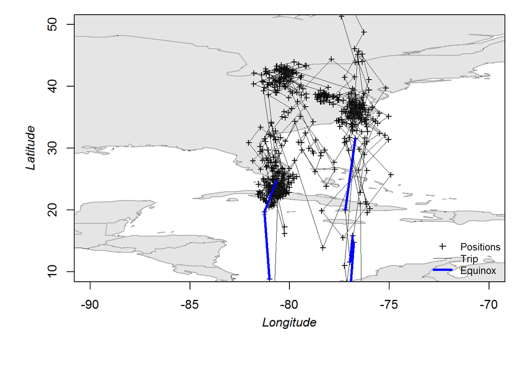

```r
##plot the data on a map
tripMap(crds = InitialPath, equinox = TRUE, xlim = c(-90,-70), ylim = c(10,50), legend = TRUE)
```

The SGAT package offers a slightly more sophisticated function to generate an initial path.

```r
InitialPath <- thresholdPath(twilight = twl$Twilight,
                             rise = twl$Rise,
                             zenith = Zenith,
                             tol = 0)
```

You can use tripmap to show the path, as we did above…

```r
tripMap(crds = InitialPath$x,
        equinox = TRUE,
        xlim = c(-90,-70),
        ylim = c(10,50),
        legend = TRUE)
```

…or here is some alternative code for making figures to show the inital path.

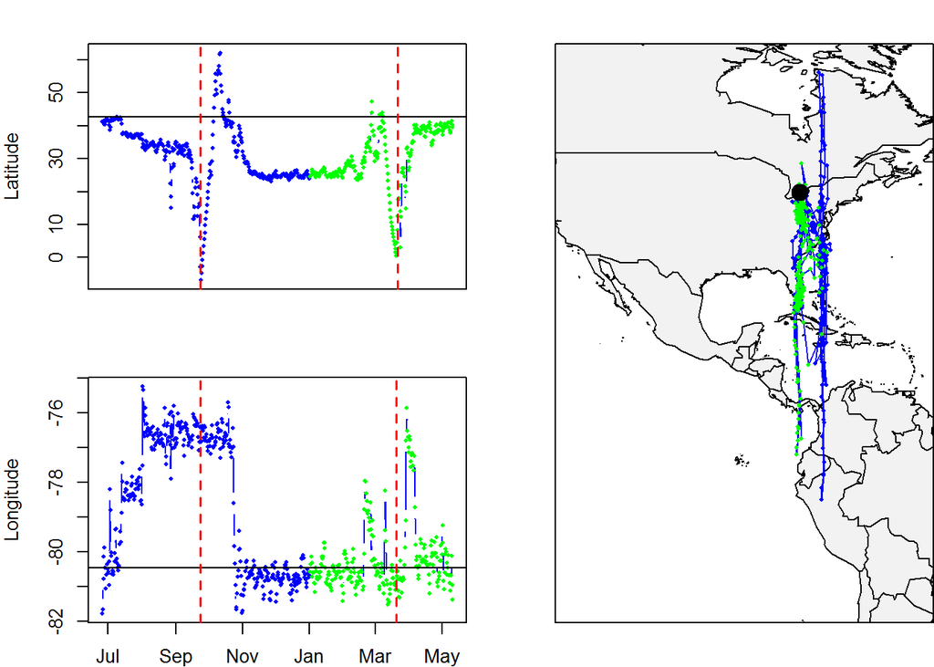

```r
year<-c("2011-01-01","2012-01-01")

  layout(matrix(c(1,3,
                  2,3), 2, 2, byrow = TRUE))

  par(mar=c(2,4,2,0))

  plot(InitialPath$time, InitialPath$x[, 2],
       type = "b",
       pch = 16,
       cex = 0.5,
       ylab = "Latitude",
       xlab = '',
       xaxt="n",
       col=ifelse(InitialPath$time<as.POSIXct(year[2],format="%Y-%m-%d"),"blue","green"))

  abline(h = CapLocs[2])
  abline(v = as.POSIXct("2011-09-23"),col="red",lty=2,lwd=1.5)
  abline(v = as.POSIXct("2012-03-21"),col="red",lty=2,lwd=1.5)

  par(mar=c(2,4,2,0))
  plot(InitialPath$time, InitialPath$x[, 1],
       type = "b",
       pch = 16,
       cex = 0.5,
       ylab = "Longitude",
       xlab = '',
       col=ifelse(InitialPath$time<as.POSIXct(year[2],format="%Y-%m-%d"),"blue","green"))

  abline(h = CapLocs[1])
  abline(v = as.POSIXct("2011-09-23"),col="red",lty=2,lwd=1.5)
  abline(v = as.POSIXct("2012-03-20"),col="red",lty=2,lwd=1.5)

  library(maptools)
  data("wrld_simpl")
  plot(wrld_simpl,
       col = "grey95",
       xlim = c(-120,-60),
       ylim=c(0,40))
 box(which="plot")
  lines(InitialPath$x,
        col = ifelse(InitialPath$time<as.POSIXct(year[2],format="%Y-%m-%d"),"blue","green"))

  points(InitialPath$x,
         pch = 16,
         cex = 0.5,
         col=ifelse(InitialPath$time<as.POSIXct(year[2],format="%Y-%m-%d"),"blue","green"))
  points(CapLocs[1],CapLocs[2],pch=19,cex=2)
```

## Creating a path with SGAT

The SGAT package contains functions that let you apply a movement model, landcover masking, and estimates of light detection error to generate a Markov Chain Monte Carlo algorithm that generates many likely movement paths from an individual data set. To run this sort of analysis we have to provide several parameters based on what we know about our data and the animal we are studying. We also have to provide an initial estimate of the movement path, which in this example will be the simple threshold path we generated above.

The workflow for creating the final path is:

1. Give the model an inital path - just created above
2. Define the mid-points between locations (needed to generate path)
3. Define a movement model (usually a distribution of flight speeds or daily flight distances wherein long flights are rare and short flights are common.)
4. Establish the error distribution for twilight detection based on your calibration data
5. (Optional) Establish a mask or grid that delineates location that are extremely unlikely to be part of the movement path (e.g. small landbirds will not reside on large water bodies).
6. Run model multiple times until model converges and throw out the first interations as burn-in
7. Refine the model further from previous runs
8. Run the model several hundred times to create the final path

### Establish a movement model

Now let’s generate some parameters for a basic movement model. We need to provide a mean and standard deviation for a gamma distribution of flight speeds that get applied to each day of the analysis period. We typically want short (near zero) distance flights to be common and long distance flights to be relatively rare. So both mean and distribution should be small.

```r
  # Flight model
beta <- c(0.7, 0.08) #mean and sd
```

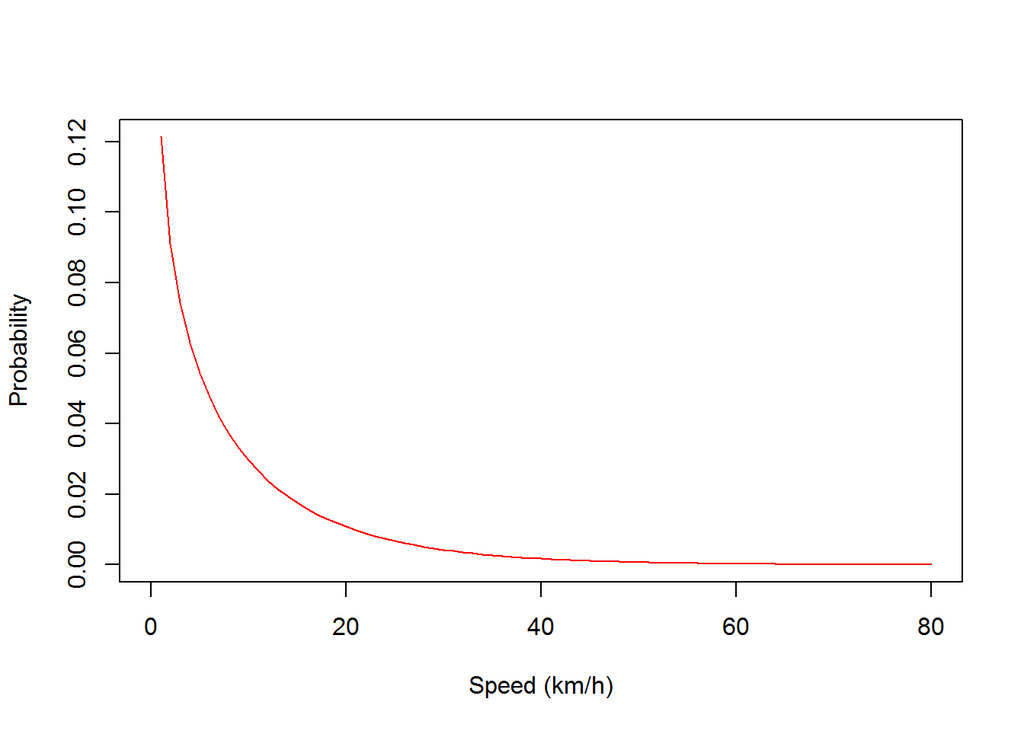

### Restrict path to land

You can restrict the path to locations on land - birds are still able to fly over water but have stationary locations on land. This makes sense for a terrestrial bird like warblers. It may not for other species, as always, consider the ecology of the species when conducting the analysis. Here, we will restrict the paths to the `wrld_simpl`.

We include a prior distribution so only locations on land within the Americas are used. We first create a function to covert the `wrld_smpl` shapefile to a binary surface.

```r
## Function to construct a land/sea mask
distribution.mask <- function(xlim, ylim, n = 4, land = TRUE, shape) {

  r <- raster(nrows = n * diff(ylim),
              ncols = n * diff(xlim),
              xmn = xlim[1],
              xmx = xlim[2],
              ymn = ylim[1],
              ymx = ylim[2],
              crs = proj4string(shape))

  r <- cover(rasterize(shape, shift = c(-360, 0), r,1, silent = TRUE),
             rasterize(shape, r, 1, silent = TRUE), rasterize(shape, r, 1, silent = TRUE))

  r <- as.matrix(is.na(r))[nrow(r):1, ]

  if (land)
    r <- !r
  xbin <- seq(xlim[1], xlim[2], length = ncol(r) + 1)
  ybin <- seq(ylim[1], ylim[2], length = nrow(r) + 1)

  function(p) {
    r[cbind(.bincode(p[, 2], ybin), .bincode(p[, 1], xbin))]
  }
}
```

Set the x and y limits for the raster surface. It’s important that you set these limits to include all longitude and latitude values where the individual may occur throughout the year. If your xlim and ylim don’t include all areas you won’t get results for that portion of the range.

```r
xlim <- c(-120,-60)
ylim <- c(0,70)
```

Here we define the distribution mask to only include stationary locations that occur on land. This makes sense for something like a Tree Swallow but may not for other species - **always** consider the ecology of the species while conducting the analysis.

```r
## Define the distribution mask
is.dist <- distribution.mask(shape=wrld_simpl,
                             xlim = xlim,
                             ylim = ylim,
                             n = 4,
                             land = TRUE)

# Define the log prior for x and z
log.prior <- function(p) {
  f <- is.dist(p)
  ifelse(f | is.na(f), 0, -10)
}
```

The log prior function produces a probability value for locations on land and locations at sea. If you feed the function a set of coordinates that is at sea the prior probilbity is -10

```r
## try a location in the Gulf of Mexico
log.prior(cbind(-90, 25))
```

```
## [1] -10
```

```r
## try a location on land
log.prior(cbind(-80, 45))
```

```
## [1] 0
```

In the SGAT package we need to specify a model for the analysis. Below we specify a few key parameters.

1. `twilight` = twilight times that we determined above.
2. `rise` = a logical vector sunrise = TRUE - this is calculated at the same time when you define twilights.
3. `twilight.model` = the distribution type for the difference between observed twilight and expected twilight.
4. `alpha` = the shape of the twilight.model distribution
5. `beta` = the movement model parameter
6. `logp.x` and `logp.z` = constraints set on the x and z (intermediate) positions. This is where you set the constraints for land
7. `x0` = initial values for the birds path (x positions)
8. `z0` = initial values for the birds path (z positions)
9. `zenith` = the zenith angle to be used. This can take a single value (no change in zenith throughout the year) or a vector of `nrow(twl)` if you want to use different zenith angles.
10. `fixedx` = a vector telling the model which locations need to be estimated because positions are unknown.

```r
# Define the threshold model - slimilar to above #

model <- thresholdModel(twilight = twl$Twilight,
                        rise = twl$Rise,
                        twilight.model = "ModifiedLogNormal",
                        alpha = alpha,
                        beta = beta,
                        # Here is where we set the constraints for land
                        logp.x = log.prior, logp.z = log.prior,
                        x0 = x0,
                        z0 = z0,
                        zenith = Zenith,
                        fixedx = fixedx)
```

We also need to define the error distribution around each location. We set that using a multivariate normal distribution

```r
# This defines the error distribution around each location #

  proposal.x <- mvnorm(S=diag(c(0.0025,0.0025)),n=nlocation(x0))
  proposal.z <- mvnorm(S=diag(c(0.0025,0.0025)),n=nlocation(z0))
```

We then fit the model using the `estelleMetropolis` sampler. Here you can set the number of iterations (`iters`), the thinning rate (`thin`) and the number of chains to run (`chains`).

```r
  fit <- estelleMetropolis(model = model,
                           proposal.x = proposal.x,
                           proposal.z = proposal.z,
                           iters = 1000, # This value sets the number of iterations to run
                           thin = 10,
                           chains = 3)

### Fine Tuning

proposal.x <- mvnorm(S=diag(c(0.0025,0.0025)),n=nlocation(chainLast(fit$x)))
proposal.z <- mvnorm(S=diag(c(0.0025,0.0025)),n=nlocation(chainLast(fit$z)))

# Summarize the results of the previous chains to initialize the next model.
# This makes full use of all the data

xsum <- locationSummary(fit$x,
                        time = fit$model$time,
                        collapse = TRUE)

zsum <- locationSummary(fit$z,
                        time = fit$model$time,
                        collapse = TRUE)

fit <- estelleMetropolis(model = model,
                              proposal.x = proposal.x,
                              proposal.z = proposal.z,
                              # initialize the model using the median path from pervious runs
                              x0 = cbind(xsum$'Lon.50%',xsum$'Lat.50%'),
                              z0 = cbind(zsum$'Lon.50%',zsum$'Lat.50%'),
                              iters = 1000, # This value sets the number of iterations to run
                              thin = 10,
                              chains = 3)

# Final Run

proposal.x <- mvnorm(chainCov(fit$x),s=0.1)
proposal.z <- mvnorm(chainCov(fit$z),s=0.1)

# Note the increase in number of interations - this takes a bit longer to run
xsum <- locationSummary(fit$x,
                        time = fit$model$time,
                        collapse = TRUE)

zsum <- locationSummary(fit$z,
                        time = fit$model$time,
                        collapse = TRUE)

fit <- estelleMetropolis(model = model,
                              proposal.x = proposal.x,
                              proposal.z = proposal.z,
                              # initialize the model using the median path from pervious runs
                              x0 = cbind(xsum$'Lon.50%',xsum$'Lat.50%'),
                              z0 = cbind(zsum$'Lon.50%',zsum$'Lat.50%'),
                              iters = 5000, # This value sets the number of iterations to run
                              thin = 10,
                              chains = 3)
```

## Inital results

To view the results of the MCMC process we first need to create an empty raster to fill with the results.

```r
# This step makes an empty raster #
r <- raster(nrows=4*diff(ylim), # this sets the spatial resolution
            ncols=4*diff(xlim), # ditto
            xmn=xlim[1],
            xmx=xlim[2],
            ymn=ylim[1],
            ymx=ylim[2])
```

We can then summarize the data using the `slices` function. Here we “slice” the intermediate locations by day. You can set `breaks` to day, month, etc.

```r
  S <- slices(type="intermediate",
                   breaks="day",
                   mcmc=fit,
                   grid=r)
```

Next if we are interested in certain days or a period of interest you may want to pull out locations that fall within a certain time period. Here we extract the dates from the MCMC process.

```r
  DATES <- S$mcmc[[1]]$time[ which( S$mcmc[[1]]$rise==TRUE) ]
```

We can create objects that correspond with certain dates of interest. These objects are the rows that correpsond with the dates of interest.

```r
# Find the rows that correspond with the dates of interest

ReleaseDay <- 1
Aug01 <- which(strptime(DATES, format = "%Y-%m-%d", tz = "GMT")==as.POSIXct("2011-08-01",format="%Y-%m-%d",tz="GMT"))
Jan01 <- which(strptime(DATES, format = "%Y-%m-%d", tz = "GMT")==as.POSIXct("2012-01-01",format="%Y-%m-%d",tz="GMT"))
Mar01 <- which(strptime(DATES, format = "%Y-%m-%d", tz = "GMT")==as.POSIXct("2012-03-01",format="%Y-%m-%d",tz="GMT"))
```

We can then use the `sliceInterval` function to extract and summarize the locations between the dates of interest. For example, if we were interested in time of year when an individual is on the breeding grounds - we may specify the dates from the `ReleaseDay` until the end of the breeding season - say `Aug01`. We may also be interested in the stationary non-breeding period - say between `Jan01` and `Mar01`. *Note* these dates were chosen haphazardly for this analysis. When conducting your own analysis make sure to consider the ecology of your species.

```r
  # "Slice" the data and save all dates between Release date and August 1.
  breed <-slice(S,k=c(ReleaseDay:Aug01)) # k = c(Start Date : End Date) using row numbers
  nonbreed <- slice(S, k=c(Jan01:Mar01))
```

We can plot the results on the same map using the following code

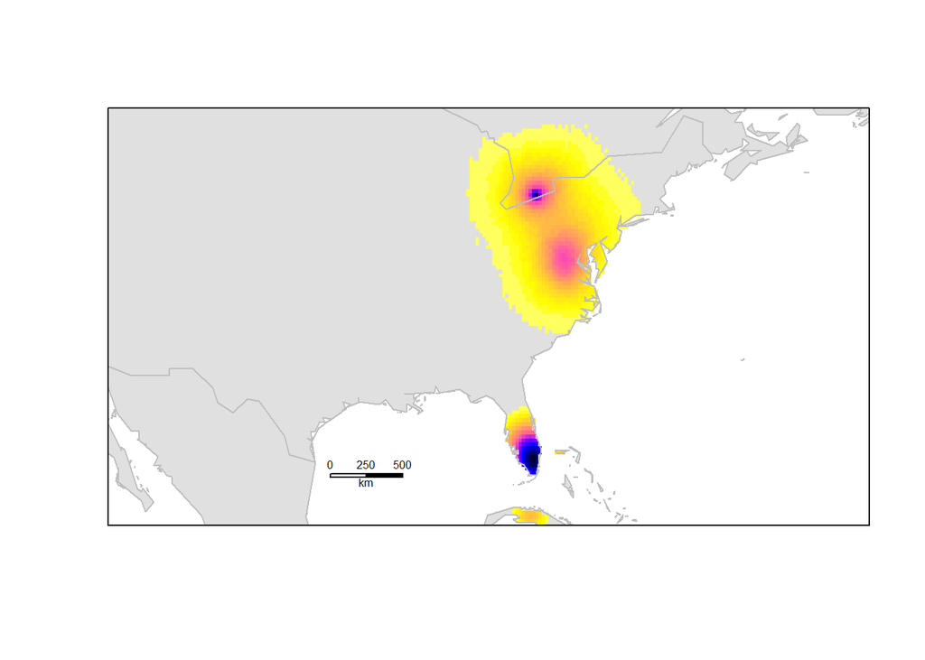

```r
  plot(wrld_simpl,
       xlim = c(-96, -72),
       ylim = c(23,47),
       border = "gray",
       col = "gray88")

  plot(breed,
       useRaster=TRUE,
       axes=FALSE,
       add=TRUE,
       legend=FALSE,
       col=c("transparent",rev(bpy.colors(50))),
       cex.axis=0.7)

  plot(nonbreed,
       useRaster=TRUE,
       axes=FALSE,
       add=TRUE,
       legend=FALSE,
       col=c(rep("transparent",5),rev(bpy.colors(50))),
       cex.axis=0.7)
  plot(wrld_simpl,border="gray",add=TRUE)
  raster::scalebar(d = 500, xy = c(-96,25),divs=2,lonlat=T,label = c(0,250,500),below="km",type="bar",cex=0.5)
  box()
```

Getting the summary statistics is fairly easy. Here we collapse all chains using the `locationSummary` function.

```r
  zummary <- locationSummary(fit$z,
                             time=fit$model$time,
                             collapse=TRUE)

  head(zummary)
```

```
##                 Time1               Time2  Lon.mean    Lon.sd   Lon.50%
## 1 2011-06-26 01:38:16 2011-06-26 09:21:26 -80.36730 0.7922839 -80.41997
## 2 2011-06-26 09:21:26 2011-06-27 01:35:25 -80.68117 1.8440814 -80.56742
## 3 2011-06-27 01:35:25 2011-06-27 09:14:25 -80.44190 0.8889717 -80.45339
## 4 2011-06-27 09:14:25 2011-06-28 01:26:55 -80.60717 2.1638810 -80.55210
## 5 2011-06-28 01:26:55 2011-06-28 09:20:25 -80.46331 0.9511520 -80.47606
## 6 2011-06-28 09:20:25 2011-06-29 01:35:25 -80.40131 1.8452306 -80.41756
##    Lon.2.5% Lon.97.5% Lat.mean    Lat.sd  Lat.50% Lat.2.5% Lat.97.5%
## 1 -81.90359 -78.52820 42.62116 0.6431913 42.62533 41.25950  43.98696
## 2 -84.92101 -77.14595 42.68093 1.3564625 42.70302 39.69091  45.29217
## 3 -82.30242 -78.50355 42.63481 0.7018839 42.63231 41.25088  44.08841
## 4 -84.96864 -76.34014 42.40590 1.6813079 42.48005 38.39968  45.71502
## 5 -82.53296 -78.44346 42.59667 0.6949587 42.61556 41.12198  44.01313
## 6 -84.12941 -76.65968 42.56895 1.2851850 42.61150 39.72451  45.23036
```

Make a plot that shows the median Longitude and Latitude through time along with the 95% credible interval.

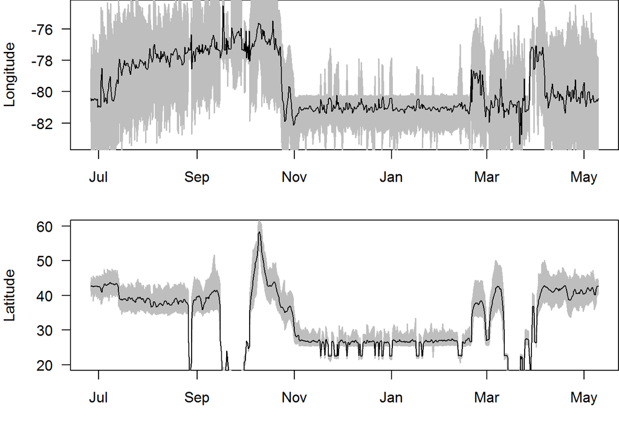

```r
par(mfrow=c(2,1),mar=c(4,4,0,0))
plot(zummary$Time1,zummary$"Lon.50%",
     type="l",
     ylab = "Longitude",
     xlab = "",
     yaxt = "n")
axis(2, las = 2)
polygon(x=c(zummary$Time1,rev(zummary$Time1)),
        y=c(zummary$`Lon.2.5%`,rev(zummary$`Lon.97.5%`)),
        border="gray",
        col="gray")
lines(zummary$Time1,zummary$"Lon.50%")
plot(zummary$Time1,zummary$"Lat.50%",
     type="l",
     ylab = "Latitude",
     xlab = "",
     yaxt = "n",
     ylim = c(20,60))
axis(2, las = 2)
polygon(x=c(zummary$Time1,rev(zummary$Time1)),
        y=c(zummary$`Lat.2.5%`,rev(zummary$`Lat.97.5%`)),
        border="gray",
        col="gray")
lines(zummary$Time1,zummary$"Lat.50%")
```

## Migratory Routes

Below are the approximate dates at each ‘stationary’ period determined via changes in the sunrise / sunset times. The summary map shows approximate location. These are just to get a general idea of when and where they stopped.

```r
library(GeoLight)

  twl.geolight <- data.frame(Twilight=twilight(fit$model$time[-length(fit$model$time)],
                                                lon= zummary$`Lon.50%`,
                                                lat=zummary$`Lat.50%`,
                                                fit$model$rise[-length(fit$model$time)],
                                                zenith=Zenith,
                                                iters=3),
                              Rise=fit$model$rise[-length(fit$model$time)])

  twl.GL <- data.frame(tFirst=twl.geolight[-nrow(twl.geolight),1],
                            tSecond=twl.geolight[-1,1],
                            type=ifelse(twl.geolight[,2],1,2)[-nrow(twl.geolight)])



  stops <- changeLight(twl = twl.GL[complete.cases(twl.GL),],
                         quantile = 0.9,
                         days = 2,
                         plot = FALSE,
                         summary = TRUE)
```

```
##
## Probability threshold(s):
##
##  Sunrise:  0.02191   Sunset:  0.021
##
##
## Migration schedule table:
##
##    Site             Arrival           Departure     P.start       P.end Days
## 1     a                <NA> 2011-07-11 17:24:37 0.000000000 0.004166667   NA
## 2     b 2011-07-14 05:19:10 2011-07-21 17:18:56 0.003333333 0.000000000  7.5
## 3     c 2011-07-23 05:20:10 2011-08-01 17:15:58 0.000000000 0.007653061  9.5
## 4     d 2011-08-05 05:16:19 2011-08-13 17:16:50 0.006944444 0.003571429  8.5
## 5     e 2011-08-15 05:15:41 2011-08-17 17:13:34 0.000000000 0.000000000  2.5
## 6     f 2011-08-19 05:15:33 2011-08-23 17:12:45 0.011666667 0.000000000  4.5
```

[output cut: 19 more lines]

```r
Sites <- mergeSites(tFirst = twl.GL$tFirst,
                    tSecond = twl.GL$tSecond,
                    type = twl.GL$type,
                    site = stops$site,
                    degElevation = 90-Zenith,
                    distThreshold = 300)
```

[figure not shown]

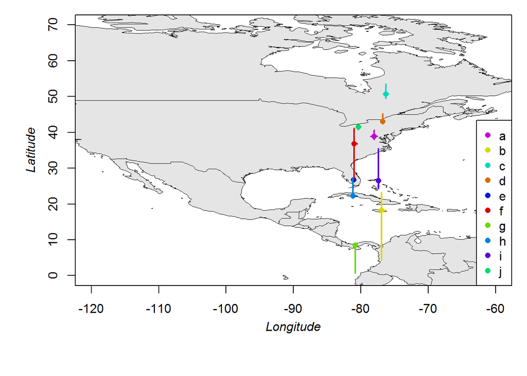

```r
siteMap(cbind(zummary$`Lon.50%`, zummary$`Lat.50%`),
          map.range="America",
          site=Sites$site,
          xlim = xlim,
          ylim = ylim,
          type='cross',hull=F,legend=FALSE)
```

back to top

# FLightR

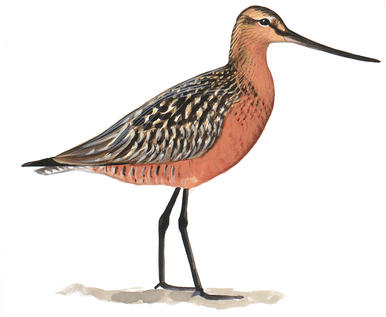

The FLightR package works really well with `.lux` files from Migrate Technology tags because of the way the light-level data are stored (lux). Here we will demonstrate the use of the FLightR package using data recovered from a Migrate Technology tag.

```r
library(FLightR)
```

## Read in data

```r
d.lux<-readMTlux("data/Godwit.lux")
```

Notice the difference between the `.lux` and the `.lig` files.

```
##                  Date    Light
## 1 2013-05-09 18:25:17 1054.931
## 2 2013-05-09 18:30:17  945.917
## 3 2013-05-09 18:35:17  178.282
## 4 2013-05-09 18:40:17  114.691
## 5 2013-05-09 18:45:17   85.167
## 6 2013-05-09 18:50:17   91.980
```

```
## 'data.frame':    117354 obs. of  2 variables:
##  $ Date : POSIXct, format: "2013-05-09 18:25:17" "2013-05-09 18:30:17" "2013-05-09 18:35:17" ...
##  $ Light: num  1054.9 945.9 178.3 114.7 85.2 ...
```

Here are what the data look like - we can plot the data using `lightImage` function.

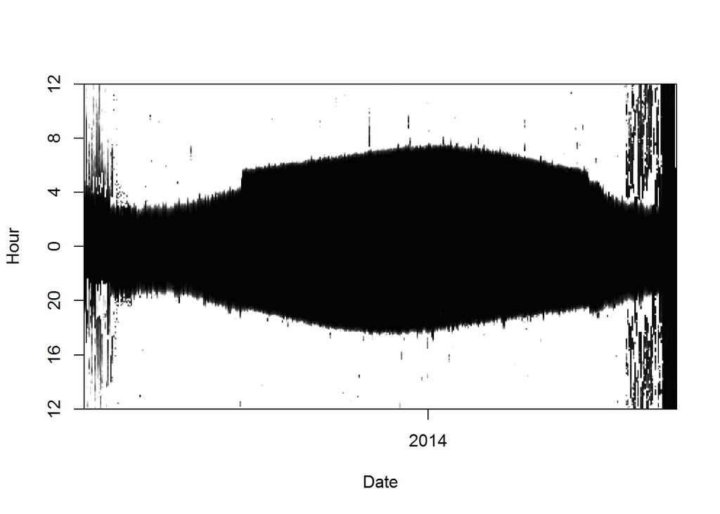

```r
lightImage( tagdata = d.lux, # light data
            offset = 12,     # adjusts the y-axis to put night (dark shades) in the middle
            zlim = c(0, 64), # y axis
            dt = 120)        # miniumn dark period
```

Define twilights

```r
seed <- as.POSIXct("2014-01-01 04:00", origin  = "1970-01-01", tz = "GMT")

twl.lux  <- findTwilights(tagdata = d.lux,
                      threshold = 1.5,
                      include = seed,
                      dark.min = 0) # minimum dark period in minutes
```

Adjust / delete outlier twilights

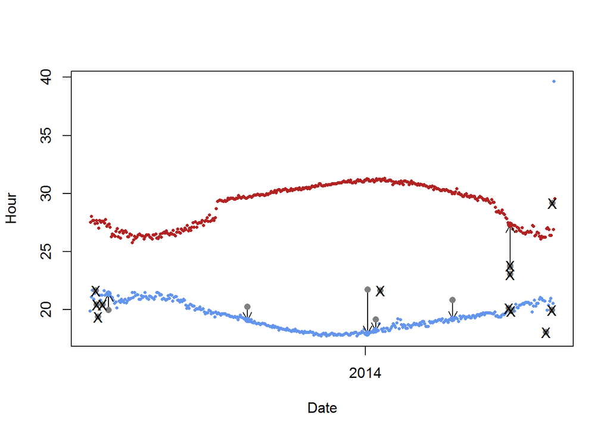

```r
twl.lux <- twilightEdit(twilights = twl.lux,
                    window = 4,           # two days before and two days after
                    outlier.mins = 45,    # difference in mins
                    stationary.mins = 25, # are the other surrounding twilights within 25 mins of one another
                    plot = TRUE)
```

Again, it’s good practice to save the twilight file so that you have a record of the twilights that were edited / deleted and make your research reproducible.

```r
write.csv(twl.lux,"Edited_Twilights.csv", quote = FALSE, row.names = FALSE)
```

Remove the transitions that were deleted by subsetting them out of the `twl.lux` data set.

```r
twl.lux <- subset(twl.lux, Deleted == FALSE)
```

```r
twl.lux$Twilight<-twl.lux$Twilight0
```

**Important** Do not adjust time of twilights like we did above for SGAT if using FLightR because it does it automatically.

Now we need to covert the data `.lux` file into a format that FLightR can use. Here we use the `BAStag2TAGS` function in the to do that.

```r
lux.tags<-BAStag2TAGS(raw = d.lux,
                      twl = twl.lux,
                      threshold = 1.5)
```

Now we write the `lux.tags` object to a file that is read in by FLightR to begin the analysis.

*NOTE* Be sure to change the file path name to match your working directory.

```r
write.csv(lux.tags,"data/Gotwit.lux.csv",quote=FALSE,row.names=FALSE)
```

```r
# opens and formats data straight from either the file we just created or TAGS formatted data.
Light.Data<-get.tags.data("data/Gotwit.lux.csv")
```

```
## Detected Intigeo_Mode_1 tag
## tag saved data every 300 seconds, and is assumed to measure data every 60 seconds, and write down max
```

Here we set the capture location

```r
# start location longitude and latitude
CapLocs=c(5.43, 52.93)
```

Next we use the data to determine the calibrartion period. During the calibration period the dawn transitions (red) and dusk transitions (black) should be very similar (overlap). Here we add two vertical lines to determine 1) the end of the first calibration period and 2) the start of the second calibration period at the end of the data before capture.

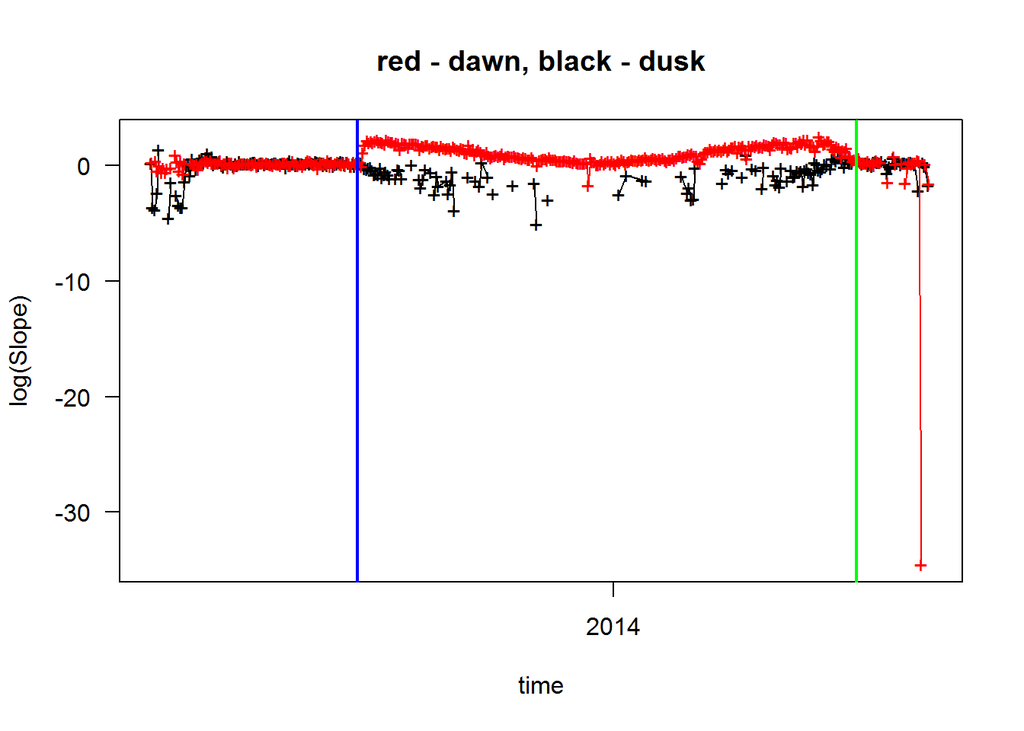

```r
plot.slopes.by.location(Proc.data = Light.Data,
                        location = CapLocs)

#Use abline to visualize potential calibration periods

# end of first calibration period
abline(v=as.POSIXct("2013-08-23"), col = "blue",lwd=2)

# start of the second calibration period
abline(v=as.POSIXct("2014-05-05"), col = "green", lwd=2)
```

Now we create a `data.frame` that includes data from each calibration period.  
The columns are: 1. start of the calibration period  
1. end of the calibration period  
1. longitude of the calibration location  
1. latitude of the calibration location

```r
#This will create two lines of data
Calibration.periods<-data.frame(calibration.start = as.POSIXct(c(NA, "2014-05-05")),
                                calibration.stop = as.POSIXct(c("2013-08-23", NA)),
                                lon = CapLocs[1],
                                lat = CapLocs[2])
```

You can also use two geographic coordinates if you have more than one calibration location. This may occur if you deploy the tag at one location and happen to capture it at a different location. You could use the following code to use two different locations. `lon = c(5.43, 6.00), lat = c(52.93,52.94)`

Here is what the calibration period data frame looks like. This object is telling FLightR to start calibration at the start of recording and stop on Aug 23 2013 and the tag was located at the location specified by the latitude, longitude. The second row tells FLightR that the second calibration period should start on May 05 2014 and continue until the end of the data set.

```r
#View results
Calibration.periods
```

```
##   calibration.start calibration.stop  lon   lat
## 1              <NA>       2013-08-23 5.43 52.93
## 2        2014-05-05             <NA> 5.43 52.93
```

Now we make a calibration object that FLightR will use to determine the relationship between recorded light-levels and the expected light-levels.

```r
#create a calibration object
Calibration<-make.calibration(Proc.data = Light.Data,
                              Calibration.periods = Calibration.periods,
                              model.ageing = FALSE,
                              plot.each = FALSE,
                              plot.final = FALSE)

#save it for later use
save(Calibration, file = "data/FLightR_calibration")
```

To read the saved calibration object we just created in later - you can use the following code.

```r
#loads object called Calibration
load("data/FLightR_calibration")
```

## Establishing spatial grid

Here we establish a spatial grid and rules for possible migration paths. The default resolution is 50 x 50km grid cells. The inputs or terms for `left`, `right`, `bottom` and `top` define your bounding box. The argument `distance.from.land.allowed.to.use` should be a vector with length of two. The first number is a negative distance allowed to use while over land (restricts birds to flying only over coastlines and water) and second is distance from land allowed to use while over water (restricts birds to flying only over coastlines and land). The `distance.from.land.allowed.to.stay` should also be a vector of length two. The first number is negative distance where the bird is allowed to be stationary (restricts birds to landing only on coastlines and land). The second value is distance from land allowed to fly over during twilight while over water (restricts birds to landing only on coastlines and water). Use infinity `c(-Inf,Inf)` to not use any restrictions. We won’t restrict paths for this example here.

```r
Grid<-make.grid(left = -14,
                bottom = 30,
                right = 13,
                top = 57,
                #Use infinity to withold restrictions on migration paths
                distance.from.land.allowed.to.use = c(-Inf, Inf),
                distance.from.land.allowed.to.stay = c(-Inf, Inf))
```

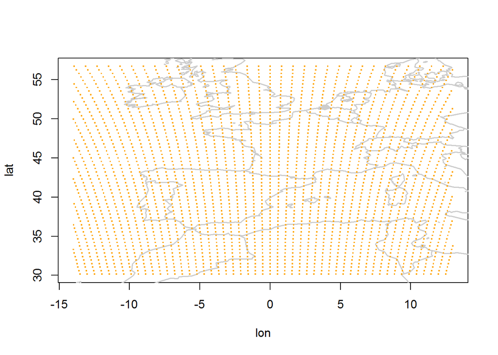

## Create a proposal

Here we create an array of settings and data that incorporates all the objects created at earlier steps:

```
- the light data with the detected twilight events (Proc.data)
- the spatial parameters (Grid)
- geographic coordinates of the starting location (start)
- the calibration parameters (Calibration)
```

This can take a while

```r
Sys.time()
a<-Sys.time()

all.in<-make.prerun.object(Proc.data = Light.Data,
                           Grid = Grid,
                           start = CapLocs, # c(Longitude, Latitude)
                           Calibration = Calibration)

Sys.time()-a
```

## Running the Particle Filter

Here is where the results are calculated (coordinates, behavior, stationarity). Within the `run.particle.filter` function, the following parameters can be preset:

```
-number of particles (1e4 is recommended for test and 1e6 for the analysis)
-known.last = TRUE if you know the track ends where it began  (FALSE is the default)
-check.outliers = TRUE, for the "on a fly" discard of outliers (only recommended to make pretty maps).
```

```r
nParticles = 1000    #just a quick trial

a <- Sys.time()

Result <- run.particle.filter(all.out = all.in,
                              threads = -1,
                              nParticles = nParticles,
                              known.last = TRUE,
                              precision.sd = 25,
                              check.outliers = FALSE)
Sys.time() - a
```

Save your results as an `.RData` object

```r
save(Result, file="data/FLightR_results.RData")
```

## Results

There is quite a lot of information in the `Result` object. You can explore these on your own.

```r
names(Result)
```

```
## [1] "Indices"     "Spatial"     "Calibration" "Data"        "Results"
```

```r
names(Result$Spatial)
```

```
## [1] "Grid"           "Behav.mask"     "start.point"    "start.location" "stop.point"     "stop.location"  "Phys.Mat"
```

```r
names(Result$Results)
```

```
## [1] "Quantiles"        "Movement.results" "outliers"         "LL"               "SD"               "Points.rle"       "Transitions.rle"  "tmp.results"
```

Have a quick look in table form

```r
print(Result$Results$Quantiles[1:5,],digits=3)
```

```
##   Min.lat FstQu.lat Medianlat Meanlat TrdQu.lat Max.lat Mode.lat Min.lon FstQu.lon Medianlon Meanlon TrdQu.lon Max.lon Mode.lon MedianlonJ MedianlatJ LCI.lat UCI.lat LCI.lon UCI.lon
## 2    53.1      53.1      53.1    53.1      53.1    53.1     53.1    5.25      5.25      5.25    5.25      5.25    5.25     5.25       5.25       53.1    53.1    53.1    5.25    5.25
## 3    50.0      50.0      50.0    50.0      50.0    50.0     49.9   11.88     11.88     11.88   11.88     11.88   11.88    11.88      11.88       50.0    49.9    49.9   11.88   11.88
## 4    50.0      50.0      50.0    50.0      50.0    50.0     49.9   11.88     11.88     11.88   11.88     11.88   11.88    11.88      11.88       50.0    49.9    49.9   11.88   11.88
## 5    54.9      54.9      54.9    54.9      54.9    54.9     54.9    9.39      9.39      9.39    9.39      9.39    9.39     9.39       9.39       54.9    54.9    54.9    9.39    9.39
## 6    54.9      54.9      54.9    54.9      54.9    54.9     54.9    9.39      9.39      9.39    9.39      9.39    9.39     9.39       9.39       54.9    54.9    54.9    9.39    9.39
##                  time
## 2 2013-05-09 15:49:16
## 3 2013-05-09 23:33:17
## 4 2013-05-10 17:03:16
## 5 2013-05-11 00:05:47
## 6 2013-05-11 17:40:11
```

```r
str(Result$Results$Quantiles)
```

```
## 'data.frame':    789 obs. of  21 variables:
##  $ Min.lat   : num  53.1 50 50 54.9 54.9 ...
##  $ FstQu.lat : num  53.1 50 50 54.9 54.9 ...
##  $ Medianlat : num  53.1 50 50 54.9 54.9 ...
##  $ Meanlat   : num  53.1 50 50 54.9 54.9 ...
##  $ TrdQu.lat : num  53.1 50 50 54.9 54.9 ...
##  $ Max.lat   : num  53.1 50 50 54.9 54.9 ...
##  $ Mode.lat  : num  53.1 49.9 49.9 54.9 54.9 ...
##  $ Min.lon   : num  5.25 11.88 11.88 9.39 9.39 ...
##  $ FstQu.lon : num  5.25 11.88 11.88 9.39 9.39 ...
##  $ Medianlon : num  5.25 11.88 11.88 9.39 9.39 ...
##  $ Meanlon   : num  5.25 11.88 11.88 9.39 9.39 ...
##  $ TrdQu.lon : num  5.25 11.88 11.88 9.39 9.39 ...
##  $ Max.lon   : num  5.25 11.88 11.88 9.39 9.39 ...
##  $ Mode.lon  : num  5.25 11.88 11.88 9.39 9.39 ...
##  $ MedianlonJ: num  5.25 11.88 11.88 9.39 9.39 ...
##  $ MedianlatJ: num  53.1 50 50 54.9 54.9 ...
##  $ LCI.lat   : num  53.1 49.9 49.9 54.9 54.9 ...
##  $ UCI.lat   : num  53.1 49.9 49.9 54.9 54.9 ...
##  $ LCI.lon   : num  5.25 11.88 11.88 9.39 9.39 ...
##  $ UCI.lon   : num  5.25 11.88 11.88 9.39 9.39 ...
##  $ time      : POSIXct, format: "2013-05-09 15:49:16" "2013-05-09 23:33:17" "2013-05-10 17:03:16" "2013-05-11 00:05:47" ...
```

```r
head(Result$Results$Movement.results)
```

```
##    Dusk           Real.time                time yday Decision Direction Kappa   M.mean M.sd M.medians Mean2report SD2report
## 4  TRUE 2013-05-09 15:49:16 2013-05-09 15:49:16  128        0   0.00000    NA      NaN   NA        NA         NaN        NA
## 5 FALSE 2013-05-09 23:33:17 2013-05-09 23:33:17  129        1 124.71897   Inf 578.0688    0  578.0688    578.0688         0
## 6  TRUE 2013-05-10 17:03:16 2013-05-10 17:03:16  129        0   0.00000    NA      NaN   NA        NA         NaN        NA
## 7 FALSE 2013-05-11 00:05:47 2013-05-11 00:05:47  130        1 -16.08636   Inf 575.8912    0  575.8912    575.8912         0
## 8  TRUE 2013-05-11 17:40:11 2013-05-11 17:40:11  130        0   0.00000    NA      NaN   NA        NA         NaN        NA
## 9 FALSE 2013-05-11 23:46:17 2013-05-11 23:46:17  131        1 169.79424   Inf 659.6917    0  659.6917    659.6917         0
```

## Plot the results

Plot a simple map

[figure not shown]

```r
#Plot a simple map
map.FLightR.ggmap(Result)
```

Plot and save a simple map

```r
map.FLightR.ggmap(Result, save.options = list(filename = "data/FLightR.map.pdf"))
```

Generate a plot that shows the longitude and latitude throughout the tracking period

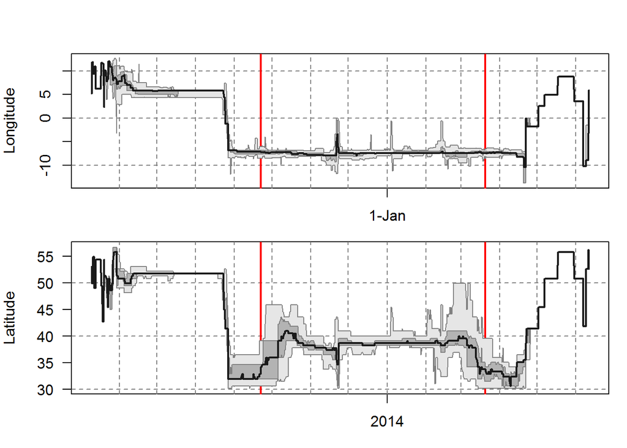

```r
plot.lon.lat(Result)
```

#### Exercise:

> Try restricting the migratory path to include only land as stationary periods.  
> Where in the process would you set that? Do the results differ? If so, how they differ?

back to top

# Data Formats

| SGAT | FLightR |
| --- | --- |
| 2011-06-26 01:38:16 | 2013-05-09T18:25:17.000Z |

[figure not shown]

[figure not shown]

[figure not shown]